# Bayesian data analysis & cognitive modeling

\[ \definecolor{firebrick}{RGB}{178,34,34} \newcommand{\red}[1]{{\color{firebrick}{#1}}} \] \[ \definecolor{mygray}{RGB}{178,34,34} \newcommand{\mygray}[1]{{\color{mygray}{#1}}} \] \[ \newcommand{\set}[1]{\{#1\}} \] \[ \newcommand{\tuple}[1]{\langle#1\rangle} \] \[\newcommand{\States}{{T}}\] \[\newcommand{\state}{{t}}\] \[\newcommand{\pow}[1]{{\mathcal{P}(#1)}}\]

## overview

## overview

- GLMs with other types of predictor variables
  - binary outcomes: logistic regression
  - nominal outcomes mulit-logit regression
  - ordinal outcomes: ordinal (logit/probit) regression
- mixed effects
- cross-validation, loo and information criteria

## recap

## generalized linear model

terminology

- \(y\) predicted variable, data, observation, …
- \(X\) predictor variables for \(y\), explanatory variables, …

blueprint of a GLM

\[ \begin{align*} \eta & = \text{linear_combination}(X) \\ \mu & = \text{link_fun}( \ \eta, \theta_{\text{LF}} \ ) \\ y & \sim \text{lh_fun}( \ \mu, \ \theta_{\text{LH}} \ ) \end{align*} \]

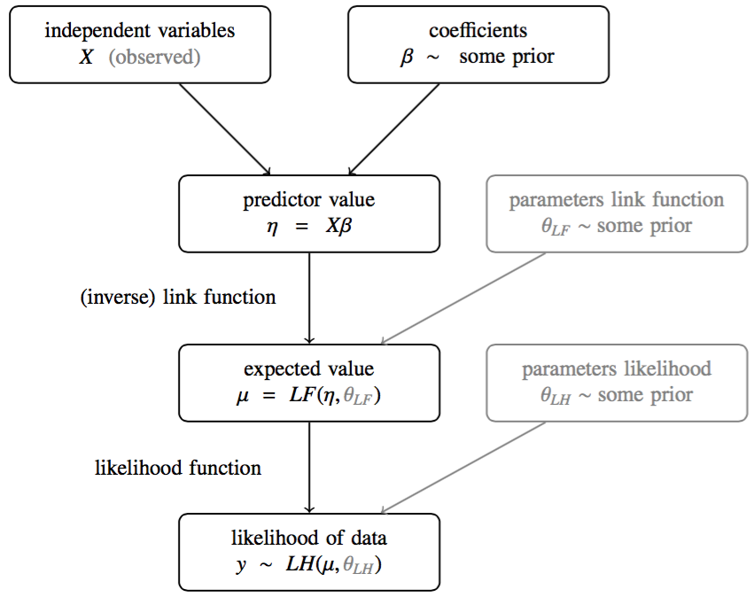

## linear regression: a Bayesian approach

Bayes: likelihood + prior

inspect posterior distribution over \(\beta_0\), \(\beta_1\) and \(\sigma_{\text{err}}\) given the data \(y\) and the model:

\[ \begin{align*} y_{\text{pred}} & = \beta_0 + \beta_1 x & \ \ \ \ \ \ \ \ \ \ \ \ \ \ y & \sim \mathcal{N}(\mu = y_{\text{pred}}, \sigma_{err}) \\ \beta_1 & \sim \mathcal{N}(0, \sigma_{\beta}) & \ \ \ \ \ \ \ \ \ \ \ \ \ \ \frac{1}{\sigma_{err}^2} & \sim \text{Gamma}(0.1,0.1) \end{align*} \]

```r
model{
  sigma_e = 1/sqrt(tau_e)
  tau_e ~ dgamma(0.1,0.1)
  b0 ~ dnorm(0, 1/10000000)
  b1 ~ dnorm(0, 1/10000000)
  for (i in 1:k){
    yPred[i] = b0 + b1 * x[i]
    y[i] ~ dnorm(yPred[i], tau_e)
  }
}
```

## GLM link functions

## common link & likelihood function

| type of \(y\) | (inverse) link function | likelihood function |
| --- | --- | --- |
| metric | \(\mu = \eta\) | \(y \sim \text{Normal}(\mu, \sigma)\) |
| binary | \(\mu = \text{logistic}(\eta, \theta, \gamma) = (1 + \exp(-\gamma (\eta - \theta)))^{-1}\) | \(y \sim \text{Binomial}(\mu)\) |
| nominal | \(\mu_k = \text{soft-max}(\eta_k, \lambda) \propto \exp(\lambda \eta_k)\) | \(y \sim \text{Multinomial}({\mu})\) |
| ordinal | \(\mu_k = \text{threshold-Phi}(\eta_k, \sigma, {\delta})\) | \(y \sim \text{Multinomial}({\mu})\) |
| count | \(\mu = \exp(\eta)\) | \(y \sim \text{Poisson}(\mu)\) |

## logistic regression for binomial data

\[ \begin{align*} \eta & = X \cdot \beta \\ \mu &= \text{logistic}(\eta, \theta = 0, \gamma = 1) = (1 + \exp(-\eta))^{-1} \\ y & \sim \text{Bernoulli}(\mu) \end{align*} \]

\[\text{logistic}(\eta, \theta, \gamma) = \frac{1}{(1 + \exp(-\gamma (\eta - \theta)))}\]

threshold \(\theta\)

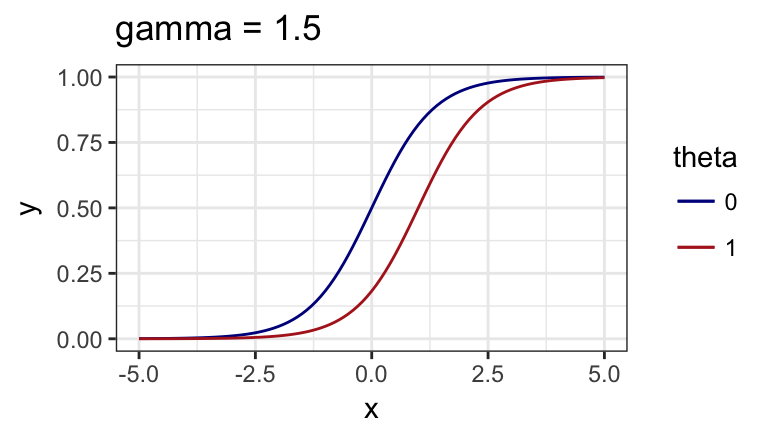

gain \(\gamma\)

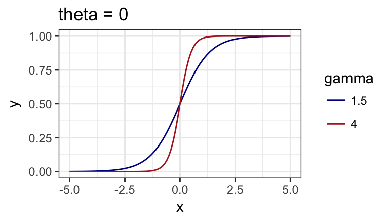

## multi-logit regression for multinomial data

\[ \begin{align*} \eta_j & = X \cdot \beta_j \\ \mu_j & \propto \exp(\eta_j) \\ y & \sim \text{Categorical}(\mu) \end{align*} \]

## ordinal (probit) regression

- each datum \(y_i \in \set{1, \dots, k}\), ordered
- \(k+1\) latent threshold parameters: \(\infty = \theta_0 < \theta_1 < \dots < \theta_k = \infty\)

## threshold-Phi model

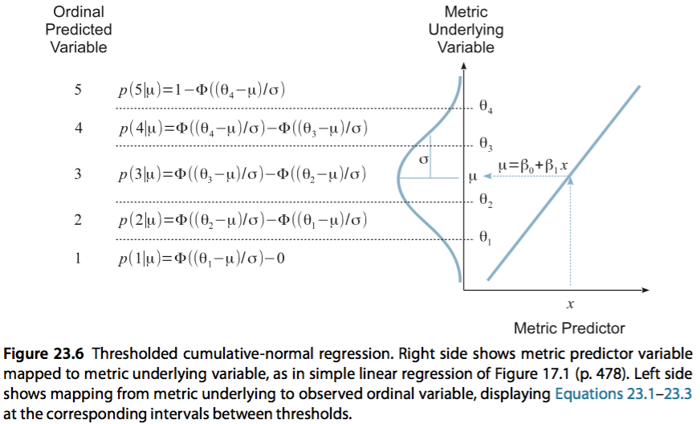

## tools for Bayesian regression

## tools for Bayesian regression

package `BayesFactor`

pro: very fast, nice comparison of nested models, good default priors on coefficients, mixed effects

con: only metric predicted variables in regression, not (easily) expandable

package `brms` (Bayesian Regression Models using Stan)

pro: efficient HMC (Stan), supports full GLM family with mixed effects, Bayes factor computation for nested models, Stan code inspection

con: slow pre-sampling phase

package `rstanarm` (Applied Regression Modelling)

pro: efficient HMC (Stan), Stan code inspection, many sources & strong development team

con: slow pre-sampling phase, not all link functions supported with mixed effects yet (?)

## mixed effects

## background on example data

- in most languages subject relative clauses  
  are easier than object relative clauses
- but Chinese seems to be an exception

subject relative clause

The senator who interrogated the journalist …

object relative clause

The senator who the journalist interrogated …

## data: self-paced reading times

37 subjects read 15 sentences either with an SRC or an ORC in a self-paced reading task

```r
rt_data = readr::read_delim('../data/08_gibsonwu2012data.txt', delim = " ") %>%
  filter(region == "headnoun") %>%
  mutate(so = ifelse(type == "subj-ext", "-1", "1")) %>%
  select(subj, item, so, rt)
head(rt_data)
```

```
## # A tibble: 6 x 4
##    subj  item    so    rt
##   <int> <int> <chr> <int>
## 1     1    13     1  1561
## 2     1     6    -1   959
## 3     1     5     1   582
## 4     1     9     1   294
## 5     1    14    -1   438
## 6     1     4    -1   286
```

\(\Leftarrow\) contrast coding of categorical predictor `so`

data from Gibson & Wu ([2013](http://tedlab.mit.edu/tedlab_website/researchpapers/Gibson_&_Wu_2013_LCP.pdf))

## inspect data

```r
rt_data %>% group_by(so) %>%
  summarize(mean_log_rt = rt%>%log%>%mean)
```

```
## # A tibble: 2 x 2
##      so mean_log_rt
##   <chr>       <dbl>
## 1    -1    6.099562
## 2     1    6.022660
```

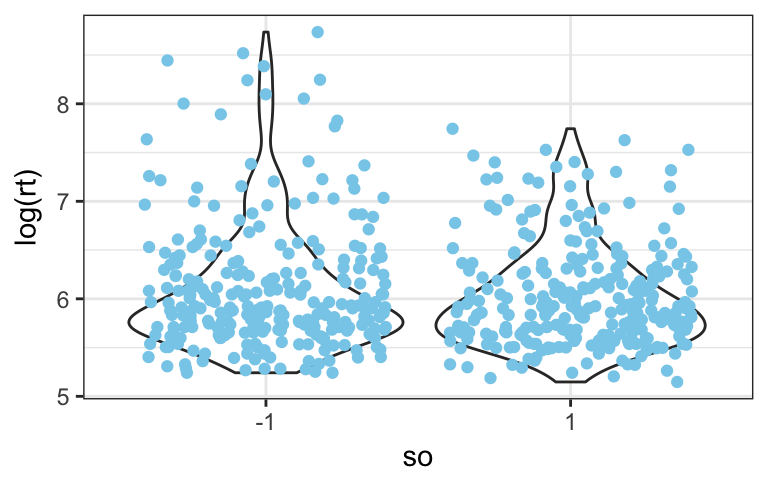

```r
rt_data %>%
ggplot(aes(x = so, y = log(rt))) +
  geom_violin() +
  geom_point(position = "jitter",
             color = "skyblue")
```

## fixed effects model

- predict log-reading times as affected by treatment `so`
- assume improper priors for parameters

\[ \begin{align*} \log(\mathtt{rt}_i) & \sim \mathcal{N}(\eta_i, \sigma_{err}) & \ \ \ \ \ \ \ \ \ \ \ \ \ \ \eta_{i} & = \beta_0 + \beta_1 \mathtt{so}_i \\ \sigma_{err} & \sim \mathcal{U}(0, \infty) & \ \ \ \ \ \ \ \ \ \ \ \ \ \ \beta_0, \beta_1 & \sim \mathcal{U}(- \infty, \infty) \end{align*} \]

```r
FE = brms::brm(log(rt) ~ so, data = rt_data) # assumes improper priors per default
```

## fixed effects model: results

```r
summary(FE)
```

```
##  Family: gaussian(identity)
## Formula: log(rt) ~ so
##    Data: rt_data (Number of observations: 547)
## Samples: 4 chains, each with iter = 2000; warmup = 1000; thin = 1;
##          total post-warmup samples = 4000
##     ICs: LOO = Not computed; WAIC = Not computed
##
## Population-Level Effects:
##           Estimate Est.Error l-95% CI u-95% CI Eff.Sample Rhat
## Intercept     6.10      0.04     6.03     6.17       3611    1
## so1          -0.08      0.05    -0.18     0.02       4000    1
##
## Family Specific Parameters:
##       Estimate Est.Error l-95% CI u-95% CI Eff.Sample Rhat
## sigma      0.6      0.02     0.56     0.64       4000    1
##
## Samples were drawn using sampling(NUTS). For each parameter, Eff.Sample
## is a crude measure of effective sample size, and Rhat is the potential
## scale reduction factor on split chains (at convergence, Rhat = 1).
```

## fixed effects model: results

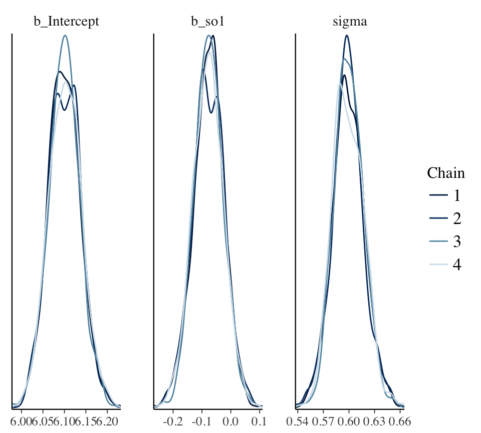

```r
brms::stanplot(FE, type = "dens_overlay")
```

## underlying Stan code

```r
brms::stancode(FE)
```

```
## // generated with brms 1.7.0
## functions {
## }
## data {
##   int<lower=1> N;  // total number of observations
##   vector[N] Y;  // response variable
##   int<lower=1> K;  // number of population-level effects
##   matrix[N, K] X;  // population-level design matrix
##   int prior_only;  // should the likelihood be ignored?
## }
## transformed data {
##   int Kc;
##   matrix[N, K - 1] Xc;  // centered version of X
##   vector[K - 1] means_X;  // column means of X before centering
##   Kc = K - 1;  // the intercept is removed from the design matrix
##   for (i in 2:K) {
##     means_X[i - 1] = mean(X[, i]);
##     Xc[, i - 1] = X[, i] - means_X[i - 1];
##   }
## }
## parameters {
##   vector[Kc] b;  // population-level effects
##   real temp_Intercept;  // temporary intercept
##   real<lower=0> sigma;  // residual SD
## }
## transformed parameters {
## }
## model {
##   vector[N] mu;
##   mu = Xc * b + temp_Intercept;
##   // prior specifications
##   sigma ~ student_t(3, 0, 10);
##   // likelihood contribution
##   if (!prior_only) {
##     Y ~ normal(mu, sigma);
##   }
## }
## generated quantities {
##   real b_Intercept;  // population-level intercept
##   b_Intercept = temp_Intercept - dot_product(means_X, b);
## }
```